# Assignment 7

## Students:

- Davíð Freyr Björnsson
- Eric Guldbrand

### B) Plot the training and testing accuracies vs the epoch as two curves in the same plot.

Changed mnist_loader.load_data_wrapper to also return training_data_zip, the training data in the same format as the test data. This set is created with

```
training_data_zip = zip(training_inputs, tr_d[1])
```

Changes were also done to `network.py` to return both training and test accuracy.

```python
# read the input data
import network
import mnist_loader
import matplotlib.pyplot as plt

def train_network(layers, epochs, batch_size, eta, mean=None, std=None, norm_reg=0):
    training_data, validation_data, test_data, training_data_zip = mnist_loader.load_data_wrapper()
    training_data = list(training_data)

    net = network.Network(layers)

    accuracy_train, accuracy_test = net.SGD(training_data, epochs=epochs, mini_batch_size=batch_size, eta=eta, test_data_train=training_data_zip, test_data_test = test_data, mean=mean, std=std, norm_reg=norm_reg)
    return accuracy_train, accuracy_test

import seaborn as sns
import pandas as pd

def plot_accuracy(accuracy_train, accuracy_test, epochs):
    alpha = 1
    df = pd.DataFrame({'epochs': range(0, epochs), 'accuracy_train': accuracy_train, 'accuracy_test': accuracy_test})
    plot = sns.scatterplot(x="epochs", y="accuracy_train", ci="sd", data=df, alpha=alpha)
    plot = sns.scatterplot(x="epochs", y="accuracy_test", ci="sd", data=df, alpha=alpha)
    plt.legend(labels=['Training accuracy', 'Test accuracy']);

def train_and_plot(layers, epochs, batch_size, eta):
    acc_train, acc_test = train_network(layers, epochs, batch_size, eta)
    plot_accuracy(acc_train, acc_test, epochs)
    return acc_train, acc_test

def train_and_repeat(layers, epochs, batch_size, eta, repeat, mean=None, std=None, norm_reg=0):
    acc_tests = []
    for i in range(0, repeat):
        acc_train, acc_test = train_network(layers, epochs, batch_size, eta, mean, std, norm_reg)
        acc_tests.append(acc_test[-1])
    return acc_tests
```

```
[========================================================================] 100%
```

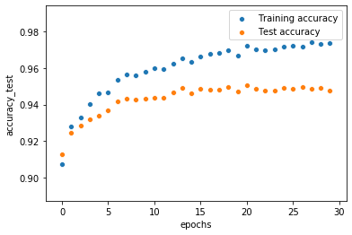

```python
acc_train, acc_test = train_and_plot([784, 30, 10], 30, 10, 3.0)
```

```python
print("Accuracy each epoch:")
print("Training:", acc_train)
print("Testing:", acc_test)
```

```
Accuracy each epoch:
Training: [0.90746, 0.92824, 0.93276, 0.94026, 0.9462, 0.94652, 0.9534, 0.95622, 0.9562, 0.95786, 0.95986, 0.95964, 0.96256, 0.96542, 0.96354, 0.96634, 0.96758, 0.96812, 0.96992, 0.9668, 0.97198, 0.97008, 0.96964, 0.97022, 0.9717, 0.9721, 0.97188, 0.974, 0.97296, 0.97376]
Testing: [0.9126, 0.9247, 0.9286, 0.9321, 0.9339, 0.937, 0.9416, 0.9433, 0.9425, 0.9432, 0.9436, 0.9439, 0.9467, 0.9492, 0.9463, 0.9485, 0.9483, 0.9479, 0.9498, 0.9473, 0.9505, 0.9484, 0.9475, 0.9476, 0.9491, 0.9486, 0.9497, 0.9486, 0.9491, 0.9475]
```

## 2) Use your program to perform the following experiments.

### a) Plot the training and testing curves for the case of a single hidden layer with 30 units and step size 3 with 30 epochs.

```
[========================================================================] 100%
```

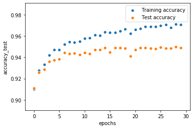

```python
train_and_plot([784, 30, 10], 30, 10, 3.0)
print()
```

## b) Change the number epochs to 10 and the number of hidden units to 100. Try different step sizes from 3 to 15. Repeat each step size 3 times. Report the testing result at the last epoch of each trial. For the learning rate with the best performance and learning rate 3, make two separate plots of performance with 30 epochs.

```python
# Returns best learning rate and corresponding accuracy
def find_best_learning_rate(layers, epochs, batch_size, etas, repeat):
    best_learning_rate = etas[0]
    max_acc = -1
    for learning_rate in etas:
        max_acc_new = max(train_and_repeat(layers, epochs, batch_size, learning_rate, 3))
        if max_acc_new > max_acc:
            best_learning_rate = learning_rate
            max_acc = max_acc_new
    return (best_learning_rate, max_acc)
```

```python
best_learning_rate = find_best_learning_rate([784, 100, 10], 10, 10, [3, 5, 10, 15], 3)
```

```python
print("Best learning rate:", best_learning_rate)
```

```
Best learning rate: (5, 0.9625)
```

```
[========================================================================] 100%
[========================================================================] 100%
```

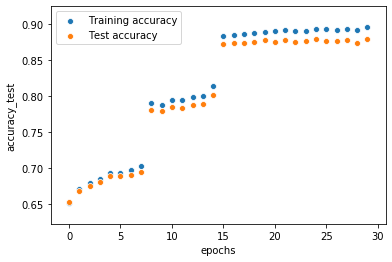

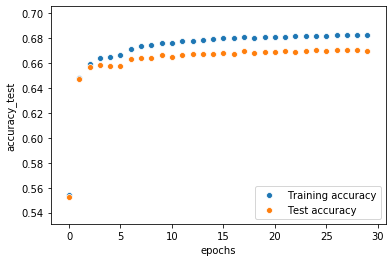

```python
train_and_plot([784, 100, 10], 30, 10, best_learning_rate[0])
plt.figure()
train_and_plot([784, 100, 10], 30, 10, 3)
print()
```

```python
keys = [10, 20, 40, 80]
unit_options = {key: None for key in keys}
best_eta = -1
best_hidden = -1
max_acc = -1

for hidden_units in keys:
    unit_options[hidden_units] = find_best_learning_rate([784, hidden_units, 10], 10, 10, [3, 5, 10, 15], 3)
```

```
hidden unit count: (best learning rate, accuracy)
{10: (3, 0.9181), 20: (3, 0.9356), 40: (5, 0.9524), 80: (5, 0.964)}
```

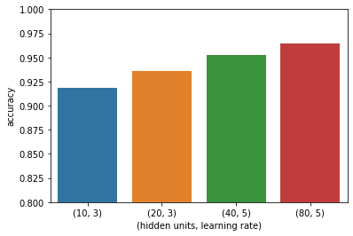

```python
for key in unit_options:
    if unit_options[key][1] > max_acc:
        max_acc = unit_options[key][1]
        best_eta = unit_options[key][0]
        best_hidden = key

accuracy = []
learning_rates = []
for key in keys:
    accuracy.append(unit_options[key][1])
    learning_rates.append(unit_options[key][0])

df = pd.DataFrame({'(hidden units, learning rate)': list(zip(keys, learning_rates)), 'accuracy': accuracy})
plot = sns.barplot(x="(hidden units, learning rate)", y="accuracy", ci="sd", data=df)
plt.ylim([0.8, 1])


print("hidden unit count: (best learning rate, accuracy)")
print(unit_options)
```

```
[========================================================================] 100%
```

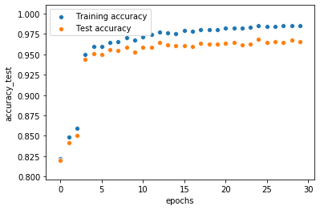

```python
# The best hidden units/learning rate combination.
# Test accuracy for 30 epochs.
train_and_plot([784, best_hidden, 10], 30, 10, best_eta)
print()
```

```python
def noise_performance(layers, epochs, batch_size, learning_rate, stds):
    accs = []
    for std in stds:
        acc = max(train_and_repeat(layers, epochs, batch_size, learning_rate, 3, mean=0, std=std))
        accs.append(acc)
    return accs

noise_accs = noise_performance([784, 30, 10], 30, 10, 3, [0, 0.5, 1, 1.5, 2])
```

```python
print("Accuracy and corresponding noise standard deviation:\n", list(zip(noise_accs, [0, 0.5, 1, 1.5, 2])))
```

```
Accuracy and corresponding noise standard deviation:
 [(0.9553, 0), (0.9412, 0.5), (0.9077, 1), (0.8864, 1.5), (0.8617, 2)]
```

### 4) Implement l_2 norm regularization.

### a) Calculate the gradient by hand.

We have that $\frac{0.001}{2}\|W\|^2 = \frac{0.001}{2}(w_1^2 +...+w_M^2)$. Therefore $\nabla (\frac{0.001}{2} \|W\|^2) = 0.001 \cdot W$

### b) Make necessary changes in the function update_mini_batch to include this gradient.

### c) With a single hidden layer with 30 units, step size 3, noise std 1 and 30 epochs, report the performance by changing the regularization parameter (0.001) from 0 to 0.002 (repeat each value three times).

```python
regs = [0, 0.001, 0.002]
accs = []
for reg in regs:
    acc = max(train_and_repeat([784, 30, 10], 30, 10, eta=3, repeat=3, mean=0, std=1, norm_reg=reg))
    accs.append(acc)

print("List of (Test accuracy, regularization parameter)")
print(list(zip(accs, regs)))
```

```
[========================================================================] 100%
[========================================================================] 100%
[========================================================================] 100%
[========================================================================] 100%
[========================================================================] 100%
[========================================================================] 100%
[========================================================================] 100%
[========================================================================] 100%
[========================================================================] 100%
```

```
List of (Test accuracy, regularization parameter)
[(0.9082, 0), (0.827, 0.001), (0.8205, 0.002)]
```